# Prediction problems: Report

## Instructions

1. This is the template you may use to submit your code and report for the prediction problems on linear and logistic regression.
2. You may modify the template if you deem fit, but it should have the information asked below.

```python
import pandas as pd
import numpy as np
import statsmodels.formula.api as smf
import seaborn as sns
import matplotlib.pyplot as plt
```

# A) Prediction problem: Linear regression

## A.1) Exploratory data analysis

Mention any major insights you obtained from the data, which you used to develop the model. You need not put any code or visualizations here.

- Insight 1: money_made_investment and out_prncp_inv have a strong negative correlation of -0.9655.
- Insight 2: both money_made_investment and out_prncp_inv have a large number of values at or very near to 0. It turns out that when out_prncp_inv is at or near 0, money_made_investment is also 0. Thus, when making predictions using the model, it may give a more accurate prediction if I manually make all the observations whose out_prncp_inv is 0 be predicted to be zero. This also means that I should only use the training data without out_prncp_inv = 0 to build the model since those observations are being veiwed as exceptions in the model and might not be beneficial in building an accurate model for the rest of the observations
- Insight 3: money_made_investment also has a seemingly significant negtaive correlation with loan_amnt (-.4), which could suggest that its a valuable predictor (this will be proven later)

## A.2) Data cleaning / preparation

Mention the data cleaning / preparation steps taken to prepare your data for developing the model. This may include imputing missing values, creating dummy variables, combining levels of categorical variable(s), discarding predictors that are not useful, etc.

```python
# Put your data cleaning/preparation code with comments here
# The code should begin from reading the train data
# The code should end when you obtain the data used to develop the model in A.4

#importing data
test = pd.read_csv('test.csv')
train = pd.read_csv('train.csv')

#filtering the training data to have only observations whose out_prncp_inv is greater than 0
train_filtered = train.loc[train.out_prncp_inv > 0]

# locating the observations in the test data whose out_prncp_inv is 0 and getting their indexes so I can find them and
# replace them with predicted values of zero after I predict using the model
test_prncp_zero = test.loc[test.out_prncp_inv == 0]
indexes = test_prncp_zero.index.tolist()

# to find significant variables to use in the model, I used forward selection:
#importing necessary libaries
import pandas as pd
import numpy as np
import statsmodels.formula.api as sm
import seaborn as sns
import matplotlib.pyplot as plt
import itertools
import time

#getting list of numeric variables to do forward selection on
lst = train._get_numeric_data().columns.tolist()
lst.pop(0)
lst.pop(0)

#setting variable for forward selection
X = train[lst]
```

```python
#Function to develop a model based on all predictors in predictor_subset
def processSubset(predictor_subset):
    # Fit model on feature_set and calculate R-squared
    # Fitting it to train_filtered, not train!!
    model = sm.ols('money_made_inv~' + '+'.join(predictor_subset),data = train_filtered).fit()
    Rsquared = model.rsquared
    return {"model":model, "Rsquared":Rsquared}
```

```python
def getBest_model(k):
    tic = time.time()
    results = []
    for combo in itertools.combinations(X.columns, k):
        results.append(processSubset((list(combo))))

    # Wrap everything up in a dataframe
    models = pd.DataFrame(results)

    # Choose the model with the highest RSS
    best_model = models.loc[models['Rsquared'].argmax()]

    toc = time.time()
    print("Processed", models.shape[0], "models on", k, "predictors in", (toc-tic), "seconds.")
    return best_model
```

```python
#Function to find the best predictor out of p-k predictors and add it to the model containing the k predictors
def forward(predictors):

    # Pull out predictors we still need to process
    remaining_predictors = [p for p in X.columns if p not in predictors]

    tic = time.time()

    results = []

    for p in remaining_predictors:
        results.append(processSubset(predictors+[p]))

    # Wrap everything up in a nice dataframe
    models = pd.DataFrame(results)

    # Choose the model with the highest RSS
    best_model = models.loc[models['Rsquared'].argmax()]

    toc = time.time()
    print("Processed ", models.shape[0], "models on", len(predictors)+1, "predictors in", (toc-tic), "seconds.")

    # Return the best model, along with some other useful information about the model
    return best_model

def forward_selection():
    models_best = pd.DataFrame(columns=["Rsquared", "model"])

    tic = time.time()
    predictors = []

    for i in range(1,len(X.columns)+1):
        models_best.loc[i] = forward(predictors)
        predictors = list(models_best.loc[i]["model"].params.index[1:])

    toc = time.time()
    print("Total elapsed time:", (toc-tic), "seconds.")
    return models_best
```

```python
models_best = forward_selection()
```

```
Processed  21 models on 1 predictors in 0.20277190208435059 seconds.
Processed  20 models on 2 predictors in 0.21179938316345215 seconds.
Processed  19 models on 3 predictors in 0.25810956954956055 seconds.
Processed  18 models on 4 predictors in 0.29715728759765625 seconds.
Processed  17 models on 5 predictors in 0.33231496810913086 seconds.
Processed  16 models on 6 predictors in 0.3176400661468506 seconds.
Processed  15 models on 7 predictors in 0.3158283233642578 seconds.
Processed  14 models on 8 predictors in 0.34925127029418945 seconds.
Processed  13 models on 9 predictors in 0.33355045318603516 seconds.
Processed  12 models on 10 predictors in 0.271803617477417 seconds.
Processed  11 models on 11 predictors in 0.2669825553894043 seconds.
Processed  10 models on 12 predictors in 0.23870301246643066 seconds.
Processed  9 models on 13 predictors in 0.23409080505371094 seconds.
Processed  8 models on 14 predictors in 0.2429039478302002 seconds.
Processed  7 models on 15 predictors in 0.23804783821105957 seconds.
Processed  6 models on 16 predictors in 0.15007758140563965 seconds.
Processed  5 models on 17 predictors in 0.17892885208129883 seconds.
Processed  4 models on 18 predictors in 0.1489729881286621 seconds.
Processed  3 models on 19 predictors in 0.12408971786499023 seconds.
Processed  2 models on 20 predictors in 0.07905817031860352 seconds.
Processed  1 models on 21 predictors in 0.04102969169616699 seconds.
Total elapsed time: 4.925013065338135 seconds.
```

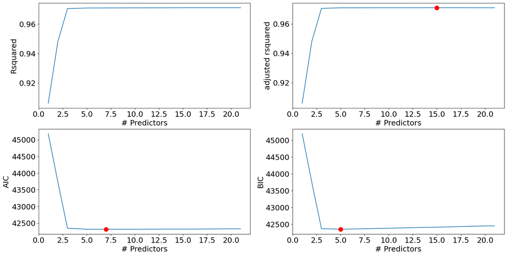

```python
def best_sub_plots():
    plt.figure(figsize=(20,10))
    plt.rcParams.update({'font.size': 18, 'lines.markersize': 10})

    # Set up a 2x2 grid so we can look at 4 plots at once
    plt.subplot(2, 2, 1)

    # We will now plot a red dot to indicate the model with the largest adjusted R^2 statistic.
    # The argmax() function can be used to identify the location of the maximum point of a vector
    plt.plot(models_best["Rsquared"])
    plt.xlabel('# Predictors')
    plt.ylabel('Rsquared')

    # We will now plot a red dot to indicate the model with the largest adjusted R^2 statistic.
    # The argmax() function can be used to identify the location of the maximum point of a vector

    rsquared_adj = models_best.apply(lambda row: row[1].rsquared_adj, axis=1)

    plt.subplot(2, 2, 2)
    plt.plot(rsquared_adj)
    plt.plot(1+rsquared_adj.argmax(), rsquared_adj.max(), "or")
    plt.xlabel('# Predictors')
    plt.ylabel('adjusted rsquared')

    # We'll do the same for AIC and BIC, this time looking for the models with the SMALLEST statistic
    aic = models_best.apply(lambda row: row[1].aic, axis=1)

    plt.subplot(2, 2, 3)
    plt.plot(aic)
    plt.plot(1+aic.argmin(), aic.min(), "or")
    plt.xlabel('# Predictors')
    plt.ylabel('AIC')

    bic = models_best.apply(lambda row: row[1].bic, axis=1)

    plt.subplot(2, 2, 4)
    plt.plot(bic)
    plt.plot(1+bic.argmin(), bic.min(), "or")
    plt.xlabel('# Predictors')
    plt.ylabel('BIC')
best_sub_plots()
```

```python
#even though the best model based on BIC is shown to contain 5 predictors, it is given to us in
# Assignment E that only four predictors are needed, so I'm only going to find the best model containing 4 predictors
best_subset_model = models_best.loc[4,'model']
best_subset_model.summary()
```

OLS Regression Results

| Dep. Variable: | money_made_inv | R-squared: | 0.971 |
| --- | --- | --- | --- |
| Model: | OLS | Adj. R-squared: | 0.971 |
| Method: | Least Squares | F-statistic: | 2.026e+04 |
| Date: | Wed, 15 Mar 2023 | Prob (F-statistic): | 0.00 |
| Time: | 20:37:04 | Log-Likelihood: | -21161. |
| No. Observations: | 2444 | AIC: | 4.233e+04 |
| Df Residuals: | 2439 | BIC: | 4.236e+04 |
| Df Model: | 4 |  |  |
| Covariance Type: | nonrobust |  |  |

|  | coef | std err | t | P>\|t\| | [0.025 | 0.975] |
| --- | --- | --- | --- | --- | --- | --- |
| Intercept | -3406.9636 | 92.355 | -36.890 | 0.000 | -3588.065 | -3225.862 |
| out_prncp_inv | -1.2540 | 0.006 | -206.010 | 0.000 | -1.266 | -1.242 |
| loan_amnt | 0.3163 | 0.005 | 59.965 | 0.000 | 0.306 | 0.327 |
| int_rate | 259.3957 | 5.970 | 43.447 | 0.000 | 247.688 | 271.103 |
| mort_acc | 63.6072 | 15.317 | 4.153 | 0.000 | 33.572 | 93.642 |

| Omnibus: | 613.620 | Durbin-Watson: | 1.953 |
| --- | --- | --- | --- |
| Prob(Omnibus): | 0.000 | Jarque-Bera (JB): | 5137.766 |
| Skew: | 0.946 | Prob(JB): | 0.00 |
| Kurtosis: | 9.846 | Cond. No. | 7.45e+04 |

Notes:  
[1] Standard Errors assume that the covariance matrix of the errors is correctly specified.  
[2] The condition number is large, 7.45e+04. This might indicate that there are  
strong multicollinearity or other numerical problems.

Through forward selection, we’ve determined the four important predictors to be: `out_prncp_inv`, `loan_amnt`, `int_rate`, and `mort_acc`.

```python
# furthermore, the categorical columns that have only two unique values will be added to the final model created-
# the logic behind this is that there is likely some sort of tangible trend in money_made_inv between these variables
# because as they only contain two values, they are probably very broad specifications that could help in breaking down
# the different types of loans into general classes that are more likely to be correlated with one another
train.select_dtypes(include=['object']).describe()
```

|  | addr_state | application_type | earliest_cr_line | emp_length | emp_title | grade | home_ownership | initial_list_status | last_credit_pull_d | purpose | sub_grade | term | verification_status |
| --- | --- | --- | --- | --- | --- | --- | --- | --- | --- | --- | --- | --- | --- |
| count | 5778 | 5778 | 5778 | 5777 | 5778 | 5778 | 5778 | 5778 | 5778 | 5778 | 5778 | 5778 | 5778 |
| unique | 49 | 2 | 497 | 11 | 964 | 7 | 4 | 2 | 57 | 12 | 35 | 2 | 3 |
| top | CA | Individual | Sep-2003 | 10+ years | Teacher | C | MORTGAGE | w | Feb-2019 | debt_consolidation | C1 | 36 months | Source Verified |
| freq | 1113 | 5663 | 47 | 2096 | 341 | 1701 | 2755 | 4654 | 3621 | 3308 | 391 | 4145 | 2488 |

The three categorical variables with 2 unique values are `application_type`, `initial_list_status`, and `term`

## A.4) Model equation

```python
# Put the code that develops the model using the data you obtained in A.2,
# and then uses the developed model on test data for prediction.

# Creating a dataframe that will consist of all combinations of polynomial transformations of the
# predictors to be considered for interactions

predictor_set = ['out_prncp_inv','loan_amnt','int_rate','mort_acc']
from itertools import product
values = np.arange(0,4)
polynomial_transformations = pd.DataFrame(product(values, repeat=4), columns=predictor_set).loc[1:,]
polynomial_transformations.loc[:,'sum_degree'] = (polynomial_transformations).astype(int).sum(axis=1)
polynomial_transformations.loc[:,'count_zeros'] = (polynomial_transformations == 0).astype(int).sum(axis=1)
polynomial_transformations.sort_values(by = ['count_zeros', 'sum_degree'], ascending=[False, True], inplace=True)
polynomial_transformations.drop(columns = ['count_zeros'], inplace=True)
polynomial_transformations.reset_index(inplace = True, drop = True)
```

```python
#Setting the seed as we are shuffling the data before splitting it into K-folds
np.random.seed(123)
# Shuffling the training set before creating K folds
train = train_filtered.sample(frac=1)
k = 5 #5-fold cross validation
fold_size = np.round(train.shape[0]/k)
```

```python
from sklearn.model_selection import KFold
def KFoldCV(selected_interactions, interaction_being_tested):
    kf = KFold(n_splits=5)
    kf.get_n_splits(train)
    total_rmse = 0
    for i, (train_index, test_index) in enumerate(kf.split(train)):
        model = sm.ols('money_made_inv~out_prncp_inv+loan_amnt+int_rate+mort_acc'\
                       +selected_interactions+interaction_being_tested, data = train.iloc[train_index]).fit()
        pred_money_made_inv = model.predict(train.iloc[test_index])
        rmse = np.sqrt(((train.money_made_inv - pred_money_made_inv)**2).mean())
        total_rmse += rmse
    return total_rmse/k
```

```python
# This code implements the algorithm of systematically considering interactions of degree 2 and going upto
# the interaction of degree 12. For a given degree 'd' the interactions are selected greedily based on
# highest reduction in the 5-fold cross validation RMSE. Once no more reduction in the 5-fold cross validation
# RMSE is possible using interactions of degree 'd', interaction terms of the next higher degree 'd+1' are considered.

# 5-fold cross validation RMSE of the initial model with the 4 predictors of degree one
cv_previous_model = KFoldCV(selected_interactions = '', interaction_being_tested = '')
interaction_being_tested = '+'
selected_interactions = ''

# Considering interactions of degree 'd' = 2 to 12
for d in np.arange(2,13):

    # Selecting interaction terms of degree = 'd'
    degree_set = polynomial_transformations.loc[polynomial_transformations.sum_degree==d, :]

    # Initializing objects to store the interactions of degree 'd' that reduce the
    # 5-fold cross validation RMSEs as compared to the previous model
    interactions_that_reduce_KfoldCV = []; cv_degree = [];

    # Creating another DataFrame that will consist of the updated set of interactions of degree 'd' to be considered
    # as interactions that do not reduce the 5-fold cross validation RMSE will be discarded
    degree_set_updated = pd.DataFrame(columns = degree_set.columns)

    # Continue adding interactions of degree 'd' in the model until no interactions reduce
    # the 5-fold cross-validation RMSE
    while True:

        #Iterating over all possible interactions of degree 'd'
        for index, row in degree_set.iterrows():

            # Creating the formula expression for the interaction term to be tested
            for predictor in predictor_set:
                interaction_being_tested = interaction_being_tested + ('I('+predictor +'**' +\
                                         str(row[predictor]) + ')*' if row[predictor]>1 else\
                                               predictor + '*' if row[predictor]==1 else '')
            interaction_being_tested = interaction_being_tested[:-1]

            # Call the function 'KFoldCV' to find out the 5-fold cross validation error on adding the
            # interaction term being tested to the model
            cv = KFoldCV(selected_interactions, interaction_being_tested)

            # If the interaction term being tested reduces the 5-fold cross validation RMSE as compared to the
            # previous model, then consider adding it to the model
            if cv<cv_previous_model:
                interactions_that_reduce_KfoldCV.append(interaction_being_tested)
                cv_degree.append(cv)
                degree_set_updated = pd.concat([degree_set_updated, row.to_frame().T])
            interaction_being_tested = '+'
        cv_data = pd.DataFrame({'interaction':interactions_that_reduce_KfoldCV, 'cv':cv_degree})

        # Sort the interaction terms that reduce the 5-fold cross valdiation RMSE based on their respective
        # 5-fold cross validation RMSE
        cv_data.sort_values(by = 'cv', inplace = True)

        # Break the loop if no interaction of degree 'd' reduces the 5-fold cross validation RMSE as
        # compared to the previous model
        if cv_data.shape[0]==0:
            break

        # Select the interaction that corresponds to the least 5-fold cross validation RMSE
        selected_interactions = selected_interactions + cv_data.iloc[0,0]
        cv_previous_model = cv_data.iloc[0,1]
        cv_degree = []; interactions_that_reduce_KfoldCV = []
        degree_set = degree_set_updated.copy()
        degree_set_updated = pd.DataFrame(columns = degree_set.columns)

        # Print the progress after each model update, i.e., after an interaction term is selected
        print("Degree of interactions being considered:",d, ", 5-fold CV RMSE:", cv_previous_model)
```

```
Degree of interactions being considered: 2 , 5-fold CV RMSE: 1197.2577214094372
Degree of interactions being considered: 2 , 5-fold CV RMSE: 1110.4086700044138
Degree of interactions being considered: 2 , 5-fold CV RMSE: 1091.6923135870397
Degree of interactions being considered: 3 , 5-fold CV RMSE: 1016.9290231660698
Degree of interactions being considered: 3 , 5-fold CV RMSE: 983.733722169692
Degree of interactions being considered: 3 , 5-fold CV RMSE: 976.6374753319881
Degree of interactions being considered: 3 , 5-fold CV RMSE: 972.9338302929616
Degree of interactions being considered: 3 , 5-fold CV RMSE: 969.1021949497124
Degree of interactions being considered: 3 , 5-fold CV RMSE: 968.909702070366
Degree of interactions being considered: 4 , 5-fold CV RMSE: 951.4943764150685
Degree of interactions being considered: 4 , 5-fold CV RMSE: 950.5399773388839
Degree of interactions being considered: 4 , 5-fold CV RMSE: 948.758428371331
Degree of interactions being considered: 5 , 5-fold CV RMSE: 930.8965609166264
Degree of interactions being considered: 5 , 5-fold CV RMSE: 922.3969545316471
Degree of interactions being considered: 6 , 5-fold CV RMSE: 917.027788682322
Degree of interactions being considered: 6 , 5-fold CV RMSE: 916.0439000960163
```

```python
# model without the categorical variables added in yet
cv_model = sm.ols('money_made_inv~out_prncp_inv+loan_amnt+int_rate+mort_acc'\
+selected_interactions+'', data = train_filtered).fit()
```

```python
# model with categorical variables added in
cv_model_with_cats = sm.ols('money_made_inv~out_prncp_inv+int_rate+bc_util+loan_amnt+\
term+application_type+initial_list_status'\
+selected_interactions+'', data = train_filtered).fit()
```

```python
# creating dataset that fits the necessary template and obtaining predictions
lin_regression_cv_predictions = pd.DataFrame({"id":test.iloc[:, 0], "Predicted":cv_model_with_cats.predict(test)})

#using the indexes of the observations that have out_prncp_inv values of 0 in the test data to set those predictions to 0
lin_regression_cv_predictions.Predicted.iloc[indexes] = 0
lin_regression_cv_predictions
```

|  | id | Predicted |
| --- | --- | --- |
| 0 | 1 | 0.000000 |
| 1 | 2 | 0.000000 |
| 2 | 3 | -4019.264259 |
| 3 | 4 | 0.000000 |
| 4 | 5 | 0.000000 |
| ... | ... | ... |
| 3813 | 3814 | -33572.810416 |
| 3814 | 3815 | 203.589160 |
| 3815 | 3816 | -8411.702257 |
| 3816 | 3817 | -3846.662791 |
| 3817 | 3818 | -5589.055687 |

3818 rows × 2 columns

```python
# convert dataframe to a csv file for upload:
lin_regression_cv_predictions.to_csv("lin_regression_cv_predictions.csv", index = False)
```

We’ll execute your code in Sections A.2 and A.4 sequentially, and it must produce the RMSE that you have claimed on Kaggle.

# B) Prediction problem: Logistic regression

The answers to this section may have a lot of overlap with those of the previous section. That’s fine! However, please provide complete answers to this section.

## B.1) Exploratory data analysis

Mention any major insights you obtained from the data, which you used to develop the logistic regression model. You need not put any code or visualizations here.

*They are the same exact insights I found in the regression problem!*

- Insight 1: money_made_investment and out_prncp_inv have a strong negative correlation of -0.9655.
- Insight 2: both money_made_investment and out_prncp_inv have a large number of values at or very near to 0. It turns out that when out_prncp_inv is at or near 0, money_made_investment is also 0. Thus, when making predictions using the model, it may give a more accurate prediction if I manually make all the observations whose out_prncp_inv is 0 be predicted to be zero. This also means that I should only use the training data without out_prncp_inv = 0 to build the model since those observations are being veiwed as exceptions in the model and might not be beneficial in building an accurate model for the rest of the observations
- Insight 3: money_made_investment also has a seemingly significant negtaive correlation with loan_amnt (-.4), which could suggest that its a valuable predictor (this will be proven later)

## B.2) Data cleaning / preparation

Mention the data cleaning / preparation steps taken to prepare your data for developing the model. This may include imputing missing values, creating dummy variables, combining levels of categorical variable(s), discarding predictors that are not useful, etc.

```python
# Put your data cleaning/preparation code with comments here
# The code should begin from reading the train_classification data
# The code should end when you obtain the data used to develop the model in B.4

# importing data
test_logistic = pd.read_csv('test_classification.csv')
train_logistic = pd.read_csv('train_classification.csv')

#filtering the training data to have only observations whose out_prncp_inv is greater than 0
train_logistic_filtered = train_logistic.loc[train_logistic.out_prncp_inv > 0]

# locating the observations in the logistic test data whose out_prncp_inv is 0 and getting their indexes so I can find
# them and replace them with predicted values of zero after I predict using the model
test_prncp_zero = test_logistic.loc[test_logistic.out_prncp_inv == 0]
indexes = test_prncp_zero.index.tolist()
```

```python
# Again, performing forward selection to find the useful predictors. Although the forward selection I did here performs
# OLS model selection, it still yielded the important variables, which were useful in logistic regression as well

# getting list of numeric variables to do forward selection on
lst = train_logistic._get_numeric_data().columns.tolist()
lst.pop(0)
lst.pop(0)

# setting variable for forward selection
X = train[lst]
```

```python
#Function to develop a model based on all predictors in predictor_subset
def processSubset(predictor_subset):
    # Fit model on feature_set and calculate R-squared
    model = sm.ols('hi_int_prncp_pd~' + '+'.join(predictor_subset),data = train_logistic).fit()
    Rsquared = model.rsquared
    return {"model":model, "Rsquared":Rsquared}

# all the other functions are the same as before, just gotta run them!
models_best = forward_selection()
```

```
Processed  21 models on 1 predictors in 0.24147939682006836 seconds.
Processed  20 models on 2 predictors in 0.3108327388763428 seconds.
Processed  19 models on 3 predictors in 0.20653629302978516 seconds.
Processed  18 models on 4 predictors in 0.26949357986450195 seconds.
Processed  17 models on 5 predictors in 0.26383209228515625 seconds.
Processed  16 models on 6 predictors in 0.26508665084838867 seconds.
Processed  15 models on 7 predictors in 0.2916700839996338 seconds.
Processed  14 models on 8 predictors in 0.2838759422302246 seconds.
Processed  13 models on 9 predictors in 0.2996790409088135 seconds.
Processed  12 models on 10 predictors in 0.2687947750091553 seconds.
Processed  11 models on 11 predictors in 0.2993204593658447 seconds.
Processed  10 models on 12 predictors in 0.2837555408477783 seconds.
Processed  9 models on 13 predictors in 0.284210205078125 seconds.
Processed  8 models on 14 predictors in 0.27773451805114746 seconds.
Processed  7 models on 15 predictors in 0.26087403297424316 seconds.
Processed  6 models on 16 predictors in 0.24530744552612305 seconds.
Processed  5 models on 17 predictors in 0.15625572204589844 seconds.
Processed  4 models on 18 predictors in 0.1575942039489746 seconds.
Processed  3 models on 19 predictors in 0.13686394691467285 seconds.
Processed  2 models on 20 predictors in 0.09449100494384766 seconds.
Processed  1 models on 21 predictors in 0.056040287017822266 seconds.
Total elapsed time: 5.066784858703613 seconds.
```

```python
# I again assumed that 4 predictors would suffice for the logistic regression (this was a hunch, but it ended up being
# correct)
best_subset_model = models_best.loc[4,'model']
best_subset_model.summary()
```

OLS Regression Results

| Dep. Variable: | hi_int_prncp_pd | R-squared: | 0.354 |
| --- | --- | --- | --- |
| Model: | OLS | Adj. R-squared: | 0.354 |
| Method: | Least Squares | F-statistic: | 791.6 |
| Date: | Wed, 15 Mar 2023 | Prob (F-statistic): | 0.00 |
| Time: | 20:38:42 | Log-Likelihood: | -1482.0 |
| No. Observations: | 5778 | AIC: | 2974. |
| Df Residuals: | 5773 | BIC: | 3007. |
| Df Model: | 4 |  |  |
| Covariance Type: | nonrobust |  |  |

|  | coef | std err | t | P>\|t\| | [0.025 | 0.975] |
| --- | --- | --- | --- | --- | --- | --- |
| Intercept | -0.0625 | 0.014 | -4.571 | 0.000 | -0.089 | -0.036 |
| out_prncp_inv | 3.163e-05 | 6.18e-07 | 51.158 | 0.000 | 3.04e-05 | 3.28e-05 |
| int_rate | 0.0181 | 0.001 | 20.630 | 0.000 | 0.016 | 0.020 |
| loan_amnt | -6.724e-06 | 5.01e-07 | -13.419 | 0.000 | -7.71e-06 | -5.74e-06 |
| acc_open_past_24mths | -0.0037 | 0.001 | -2.859 | 0.004 | -0.006 | -0.001 |

| Omnibus: | 628.646 | Durbin-Watson: | 1.977 |
| --- | --- | --- | --- |
| Prob(Omnibus): | 0.000 | Jarque-Bera (JB): | 1015.186 |
| Skew: | 0.775 | Prob(JB): | 3.59e-221 |
| Kurtosis: | 4.346 | Cond. No. | 6.30e+04 |

Notes:  
[1] Standard Errors assume that the covariance matrix of the errors is correctly specified.  
[2] The condition number is large, 6.3e+04. This might indicate that there are  
strong multicollinearity or other numerical problems.

Through forward selection, we’ve determined the four important predictors to be: `out_prncp_inv`, `int_rate`, `loan_amnt`, and `acc_open_past_24mths`.

```python
# furthermore, the categorical columns that have only two unique values will be added to the final model created-
# the logic behind this is that there is likely some sort of tangible trend in money_made_inv between these variables
# because as they only contain two values, they are probably very broad specifications that could help in breaking down
# the different types of loans into general classes that are more likely to be correlated with one another
train.select_dtypes(include=['object']).describe()
```

|  | addr_state | application_type | earliest_cr_line | emp_length | emp_title | grade | home_ownership | initial_list_status | last_credit_pull_d | purpose | sub_grade | term | verification_status |
| --- | --- | --- | --- | --- | --- | --- | --- | --- | --- | --- | --- | --- | --- |
| count | 2444 | 2444 | 2444 | 2444 | 2444 | 2444 | 2444 | 2444 | 2444 | 2444 | 2444 | 2444 | 2444 |
| unique | 48 | 2 | 424 | 11 | 546 | 7 | 4 | 2 | 12 | 12 | 34 | 2 | 3 |
| top | CA | Individual | Jul-2002 | 10+ years | Teacher | B | MORTGAGE | w | Feb-2019 | debt_consolidation | B1 | 36 months | Source Verified |
| freq | 434 | 2354 | 25 | 899 | 177 | 732 | 1135 | 2192 | 2419 | 1343 | 162 | 1643 | 1014 |

The three categorical variables with 2 unique values are `application_type`, `initial_list_status`, and `term`

## B.4) Model equation

```python
# Put the code that develops the model using the data you obtained in B.2,
# and then uses the developed model on test_classification data for prediction.
```

```python
# fitting the model with the 4 predictors, selected interactions, and 3 categorical variables
logit_model = sm.logit('hi_int_prncp_pd~out_prncp_inv+int_rate+bc_util+loan_amnt+\
term+application_type+initial_list_status'\
+selected_interactions+'', data = train_logistic_filtered).fit()
```

```
Optimization terminated successfully.
         Current function value: 0.475210
         Iterations 7
```

```python
# making predictions
logistic_prediction = logit_model.predict(test_logistic)
logistic_prediction
```

```
0       0.099614
1       0.079460
2       0.472891
3       0.118532
4       0.804451
          ...
3813    0.452204
3814    0.074014
3815    0.289652
3816    0.172522
3817    0.859871
Length: 3818, dtype: float64
```

```python
# creating data frame with necessary template
predictions = pd.DataFrame({"id":test_logistic.iloc[:, 0], "Category":logit_model.predict(test_logistic)})
```

```python
#finding the correct decision threshold (done through trial and error)
predictions_above = predictions.loc[predictions.Category > .45 ]
predictions_below = predictions.loc[predictions.Category < .45 ]
```

```python
#setting values above the threshold to 1 and values below the threshold to 0
index_above = predictions_above.index.tolist()
index_below = predictions_below.index.tolist()
predictions.iloc[index_above] = 1
predictions.iloc[index_below] = 0
```

```python
# setting observations whose out_prncp_inv is 0 to 0 as well
indexes = test_prncp_zero.index.tolist()
predictions.iloc[indexes] = 0
```

```python
predictions.value_counts()
```

```
id  Category
0   0.0         3209
1   1.0          609
dtype: int64
```

```python
predictions
```

|  | id | Category |
| --- | --- | --- |
| 0 | 0 | 0.0 |
| 1 | 0 | 0.0 |
| 2 | 0 | 0.0 |
| 3 | 0 | 0.0 |
| 4 | 1 | 1.0 |
| ... | ... | ... |
| 3813 | 0 | 0.0 |
| 3814 | 0 | 0.0 |
| 3815 | 0 | 0.0 |
| 3816 | 0 | 0.0 |
| 3817 | 1 | 1.0 |

3818 rows × 2 columns

```python
# exporting the df to a CSV file
predictions.to_csv("log_regression_cv_predictions.csv", index = False)
```

Lastly, I’m aware that the id column is not in the correct format, but whenever I would correct the format as such:

```python
predictions_copy = predictions.copy()
predictions_copy['id'] = predictions_copy.index
predictions_copy.head()
```

|  | id | Category |
| --- | --- | --- |
| 0 | 0 | 0.0 |
| 1 | 1 | 0.0 |
| 2 | 2 | 0.0 |
| 3 | 3 | 0.0 |
| 4 | 4 | 1.0 |

and then import it to a CSV file, upon submitting the file to Kaggle, I would get a score of 0! But, when I leave the dataframe as it is (ie how the `prediction` dataframe is formatted now), open the csv file, and fix the formatting in excel, I turn it in and get a score of > 93%. I have no idea why this is happening, and I’ve spent the last two hours trying to fix it to no avail. Super sorry about that, but if you do format the id correctly in excel and submit my predictions, you should get the correct score on Kaggle. Hope that’s okay.

We’ll execute your code in Sections B.2 and B.4 sequentially, and it must produce the classification accuracy that you have claimed on Kaggle.